# A Commentary on *Exposure to air pollution and COVID-19 mortality in the United States*

This R notebook will detail a qualitative and quantitative review of the *Exposure to air pollution and COVID-19 mortality in the United States* by Xiao Wu, Rachel C. Nethery, M. Benjamin Sabath, Danielle Braun, and Francesca Dominici. The paper studies the relationship between long-term $PM_{2.5}$ exposure and COVID-19 deaths. The study uses uses county level COVID-19 data (deaths and cases), historical spatiotemporal $PM_{2.5}$ data, as well as several other datasets that the authors use as control and FE variables.

The authors use a zero-inflated negative binomial mixed model to estimate the relationship between $PM_{2.5}$ and COVID-19 deaths. The results claim that an increase of 1$\mu g/m^3$ of $PM_{2.5}$ leads to a large increase in COVID-19 death rate. This is quite a significant claim, since it clearly states a causal relationship between long term $PM_{2.5}$ exposure and increased likelihood of death from COVID-19. Professor Dominici was quoted by National Geographic that ``If you’re getting COVID, and you have been breathing polluted air, it’s really putting gasoline on a fire". The authors released all their code and the data they use for the analysis on a GitHub repository: https://github.com/wxwx1993/PM_COVID (yay to open source research!!).

The single biggest problem with this paper in my opinion is that pollution is endogeneous, meaning it is corrolated with error, meaning it is corrolated with a host of variables that also have health implications. Controlling for confounding variables does not make the relationship causal. This is the reason for methods such as Instrumental Variables, Difference-in-Difference, Regression Discontinuity, and many others I will not name here. To be honest, I feel like I must be missing something, since the lead author on this paper, Professor Dominici is a well respected Statistician at Harvard’s Biostatistics department. Surely, I am missing something on the validity of the study. The study has been widely cited in news articles and has been mostly accepted to be rigorous in analysis.

First, I have added a couple lines to the end of the preprocessing file to add some additional variables that will be used in the analysis (feel free to look at this on ozaltun/PM_COVID - forked repository from wxwx1993).

```r
library("tidyr")
library("pscl")
library("MASS")
library(NBZIMM)
library("lfe")
library("lme4")
library("stargazer")

source('Preprocessing_v2.R')
```

Now lets run the main analysis that the paper runs:

```r
# main analysis
glmm.zinb.off = glmm.zinb(fixed = Deaths ~ mean_pm25 +scale(poverty) + scale(popdensity)  +scale(medianhousevalue)
                          +scale(medhouseholdincome) + scale(pct_owner_occ)  +scale(hispanic)
                          +scale(education)  +scale(pct_blk) + scale(older_pecent)
                          + scale(totalTestResults) +
                            + scale(beds)
                          + scale(mean_bmi) + scale(smoke_rate)
                          + scale(mean_summer_temp) + scale(mean_winter_temp) + scale(mean_summer_rm) + scale(mean_winter_rm)
                          + offset(log(population)),
                          random = ~ 1 | state, data = (aggregate_pm_census_cdc_test_beds))
```

```
## Computational iterations: 13
## Computational time: 0.029 minutes
```

We can look at the Estimate and the 95% CI of $PM_{2.5}$:

```r
intervals(glmm.zinb.off, level=0.95)$fixed[2,]
```

```
##      lower       est.      upper
## 0.07211898 0.14852232 0.22492567
```

As shown in the paper, the correlation between $PM_{2.5}$ in this setup is large and significant. One aspect I find to be misleading in this paper is that they discuss that they use data from 3088 counties, but don’t mention how many counties their main analysis is run on:

```r
cat("N: ", glmm.zinb.off$dims$N)
```

```
## N:  1793
```

1793 is much less then 3088… So what is causing the loss of so many counties? It is the “beds”, “mean_bmi”, and “smoke_rate” variables, in total about ~1200 county values are missing. When we run the analysis withouth them:

```r
# main analysis
glmm.zinb.counties = glmm.zinb(fixed = Deaths ~ mean_pm25 +scale(poverty) + scale(popdensity)  +scale(medianhousevalue)
                          +scale(medhouseholdincome) + scale(pct_owner_occ)  +scale(hispanic)
                          +scale(education)  +scale(pct_blk) + scale(older_pecent)
                          + scale(totalTestResults)
                          + scale(mean_summer_temp) + scale(mean_winter_temp) + scale(mean_summer_rm)
                          + scale(mean_winter_rm)
                          + offset(log(population)),
                          random = ~ 1 | state, data = (aggregate_pm_census_cdc_test_beds))
```

```
## Computational iterations: 15
## Computational time: 0.037 minutes
```

```r
cat('5%, Estimate, 95%:',intervals(glmm.zinb.counties, level=0.95)$fixed[2,], '\n')
```

```
## 5%, Estimate, 95%: 0.02328971 0.08574137 0.148193
```

```r
cat("N: ", glmm.zinb.counties$dims$N)
```

```
## N:  3095
```

The results are still significant, but sort of weird that our point estimate decreased when we took out three confounding variables. And now we aren’t even controlling for beds, bmi, or smoke rate! When they run their robustness checks, they remove smoking + bmi OR beds, which increases the number of counties to approximately 2300. Still around 800 short.

Next, I would like to introduce some additional FEs and controls. Not sure how the “glmm.zinb” package works, but I would like to both control and cluster around certain variables. Additionally, on top of population density, I am interested in transportation metrics that have shown to be correlated with COVID deaths. It is important to think of the dynamics of the COVID-19 deaths we are seeing. This analysis assumes the snapshot of COVID cases and deaths are a good variable, but it doesn’t account for the temporal heterogeneity in when the virus might have started spreading in a location. This is definitely hard to capture, since testing is not perfect, but we can try to match the time variable by implementing two methods: (1) Use week of first death or week of first case as FE or (2) Use n-days after first death or first case as the y variable. I will use method (1) as it is easier to code up. For one of the regressions, we will also use deaths_per_capita as our y variable since it will capture the death rate better. I will use a FEs framework to do so as I am more familiar with, using the following general form for county i:

$$log(Deaths_i) = \beta_0 + \beta_1 PM_{2.5, i} + Controls_i + FEs_i + \epsilon_i$$
$$Deaths_i/pop_i = \beta_0 + \beta_1 PM_{2.5, i} + Controls_i + FEs_i + \epsilon_i$$
Finally, I will change the structure of some of the variables: income and educations will be restructured into 5 bins, beds will be per capita. Below we run three regressions: (1) baseline regression similar to the setup in the study, (2) changing the y variable to be deaths per capita, (3) adding transportation

```r
# Initial FE setup
output.new.1 <- felm(log(Deaths+1) ~ mean_pm25+scale(poverty) +scale(medianhousevalue)
                     + scale(pct_owner_occ)  +scale(hispanic)
                     + scale(pct_blk) + scale(older_pecent)
                     + scale(mean_summer_temp) + scale(mean_winter_temp) + scale(mean_summer_rm) + scale(mean_winter_rm)
                     + scale(totalTestResults)
                     + log(population)|factor(q_popdensity) +state+factor(first_case_week)+ factor(education_bins)+ factor(income_bins)  |0|popdensity_bins, cmethod="reghdfe", data = df)

# Looking at deaths per capita
output.new.2 <- felm(deaths_per_capita ~ mean_pm25+WRK_Drive +WRK_PublicTransit +WRK_Bike +WRK_Walk +WRKHOME+scale(poverty) +scale(medianhousevalue)
                     + scale(pct_owner_occ)  +scale(hispanic)
                     + scale(pct_blk) + scale(older_pecent)
                     + scale(mean_summer_temp) + scale(mean_winter_temp) + scale(mean_summer_rm) + scale(mean_winter_rm)
                     + scale(totalTestResults)
                     + log(population)|factor(q_popdensity) +state+factor(first_case_week)+ factor(education_bins)+ factor(income_bins)  |0|popdensity_bins, cmethod="reghdfe", data = df)



# Incorporating transportation method
output.new.3 <- felm(log(Deaths+1) ~ mean_pm25
                     +WRK_Drive +WRK_PublicTransit +WRK_Bike +WRK_Walk +WRKHOME
                     + scale(poverty) +scale(medianhousevalue)
                     + scale(pct_owner_occ)  +scale(hispanic) + scale(pct_blk) + scale(older_pecent)
                     + scale(mean_summer_temp) + scale(mean_winter_temp) + scale(mean_summer_rm) + scale(mean_winter_rm)
                     + scale(totalTestResults)
                     + log(population)
                     |factor(q_popdensity) + state + factor(first_case_week)+ factor(education_bins)+ factor(income_bins)
                     |0|popdensity_bins, cmethod="reghdfe", data = df)
```

```r
stargazer(output.new.1, output.new.3, output.new.2, title= "All counties", keep=c("mean_pm25"), omit.stat = c("LL","ser","f","rsq"), style = "qje"
          , dep.var.labels=c("log(Deaths)", "Deaths per Capita")
          , add.lines=list(c("Controls + FE", "X", "X","X"), c("Transportation", "","X", "X")), type='html')
```

**All counties**

|  | log(Deaths) |  | Deaths per Capita |
| --- | --- | --- | --- |
|  | (1) | (2) | (3) |
| mean_pm25 | 0.053*** | 0.031* | 0.00000 |
|  | (0.017) | (0.016) | (0.00000) |
| Controls + FE | X | X | X |
| Transportation |  | X | X |
| *N* | 3,061 | 3,061 | 3,061 |
| Adjusted R<sup>2</sup> | 0.675 | 0.713 | 0.483 |
| *Notes:* | ***Significant at the 1 percent level. |  |  |
|  | **Significant at the 5 percent level. |  |  |
|  | *Significant at the 10 percent level. |  |  |

```r
# Ideal regression
output.new.4 <- felm(log(Deaths + (Deaths^2+1)^0.5) ~ mean_pm25+WRK_Drive +WRK_PublicTransit +WRK_Bike +WRK_Walk +WRKHOME+poverty +medianhousevalue + pct_owner_occ  +hispanic + pct_blk +older_pecent+ mean_summer_temp + mean_winter_temp + mean_summer_rm + mean_winter_rm + totalTestResults+ log(population)|factor(q_popdensity) +factor(first_case_week) + factor(state)+ factor(education_bins)+ factor(income_bins)  |0|popdensity_bins, cmethod="reghdfe", data = df)
```

```r
stargazer(output.new.4, title= "Counties with Death>0", keep=c("mean_pm25"), omit.stat = c("LL","ser","f","rsq"), style = "qje"
          , dep.var.labels=c("hsin(Deaths)")
          , add.lines=list(c("Controls + FE", "X"), c("Transportation","X")), type='html')
```

|  | hsin(Deaths) |
| --- | --- |
| mean_pm25 | 0.038* |
|  | (0.020) |
| Controls + FE | X |
| Transportation | X |
| *N* | 3,061 |
| Adjusted R<sup>2</sup> | 0.703 |
| *Notes:* | ***Significant at the 1 percent level. |
|  | **Significant at the 5 percent level. |
|  | *Significant at the 10 percent level. |

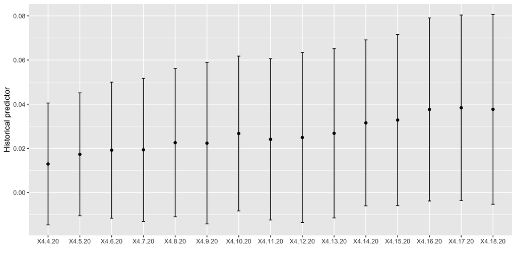

```r
library("tidyverse")
coef_list <- c()
lb_list<- c()
ub_list<-c()

for(date in time_series_columns){
  eq <- paste0("log(",date," + (",date,"^2+1)^0.5) ~ mean_pm25+WRK_Drive +WRK_PublicTransit +WRK_Bike +WRK_Walk +WRKHOME+poverty +medianhousevalue + pct_owner_occ  +hispanic + pct_blk +older_pecent+ mean_summer_temp + mean_winter_temp + mean_summer_rm + mean_winter_rm + totalTestResults+ log(population)|factor(q_popdensity) +factor(first_case_week) + factor(state)+ factor(education_bins)+ factor(income_bins)  |0|popdensity_bins")

  output.new.temp <- felm(as.formula(eq), cmethod="reghdfe", data = df)
  coef_list <- c(coef_list,coef(output.new.temp)["mean_pm25"])
  lb_list <- c(lb_list, confint(output.new.temp, level = 0.95)["mean_pm25", ][1])
  ub_list <- c(ub_list, confint(output.new.temp, level = 0.95)["mean_pm25", ][2])
}


time_series_estimate <- data.frame(est = coef_list,
                                   lb = lb_list,
                                   ub = ub_list,
                                   model = time_series_columns)
time_series_estimate$model <- factor(time_series_estimate$model, levels = time_series_estimate$model)

ggplot(time_series_estimate, aes(x = model, y = est)) +
  geom_point() +
  geom_errorbar(aes(ymin = lb, ymax = ub), width = 0.1) +
  xlab("") +
  ylab("Historical predictor")
```

I would like to say that my issue is not with the Hypothesis. Looking at what we know about the impacts of long term exposure to $PM_{2.5}$, it isn’t much of a reach to come to this conclusion. My overall quarrell is with trying to make a case for it by using statistical methods that don’t show the hypothesis to be true. Additionally, the amount of news coverage this paper has gotten even though it hasn’t been peer reviewed is troubling. It troubles me that such an analysis can be done and the results are made to seem cristal clear, when to me, far from an expert, the conclusions made by this paper are questionable at the least. I hope I have made some error and that my lack of knowledge in a specific area has caused for such a confusion, but from experts I have spoken to, this doesn’t seem likely. Such studies might gain traction in the short term, but I believe it truly hinders the long term image of environmental research by decreasing the credibility of academic research.